# Horizon Sequence Transition Probability

D.E. Beaudette  
2016-02-04  
This document is based on `aqp` version 1.9.5 and `sharpshootR` version 0.9.3.

# Setup R Envionment

If you have never used the aqp or [soildb](https://r-forge.r-project.org/scm/viewvc.php/*checkout*/docs/soilDB/soilDB-Intro.html?root=aqp) packages before, you will likely need to install them. This only needs to be done once.

```r
# stable version from CRAN + dependencies
install.packages("aqp", dep = TRUE)
install.packages("soilDB", dep = TRUE)
install.packages("sharpshootR", dep = TRUE)
install.packages("markovchain", dep = TRUE)
# latest versions from R-Forge:
install.packages("aqp", repos = "http://R-Forge.R-project.org", type = "source")
install.packages("soilDB", repos = "http://R-Forge.R-project.org", type = "source")
install.packages("sharpshootR", repos = "http://R-Forge.R-project.org", type = "source")
```

Once you have all of the R packages on which this document depends, it is a good idea to load them. R packages must be **installed** anytime you change versions of R (e.g., after an upgrade) and **loaded** anytime you want to access functions from within those packages.

```r
library(markovchain)
library(aqp)
library(sharpshootR)
library(soilDB)
library(igraph)
```

# Sample Data

While the methods outlined in this document can be applied to any collection of pedons, it is convenient to work with a standardized set of data. You can follow along with the analysis by copying code from the following blocks and running it in your **R** session. The sample data used in this document is based on soil profiles that have been correlated to the [Loafercreek](https://soilseries.sc.egov.usda.gov/OSD_Docs/L/LOAFERCREEK.html) soil series from the Sierra Nevada Foothill Region of California. Note that the internal structure of the `loafercreek` data is identical to the structure returned by [`fetchNASIS()` from the soilDB package](https://r-forge.r-project.org/scm/viewvc.php/*checkout*/docs/soilDB/soilDB-Intro.html?root=aqp). All horizon-level values are pulled from the pedon horizon table of the pedons being analyzed.

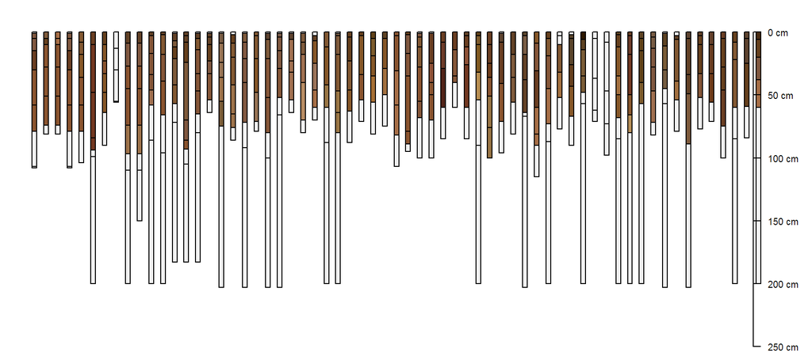

Pedons correlated to the Loafercreek soil series.

```r
# load sample data from the soilDB package
data(loafercreek, package = "soilDB")
pedons <- loafercreek
# plot profile sketches
par(mar = c(0, 0, 0, 0))
plot(pedons, name = "", print.id = FALSE, cex.names = 0.75, axis.line.offset = -4)
```

## Optional: Follow Along with Your Data

The following code block demonstrates how to pull data in using the [`fetchNASIS()` function from the soilDB package](https://r-forge.r-project.org/scm/viewvc.php/*checkout*/docs/soilDB/soilDB-Intro.html?root=aqp).

```r
# first load the desired data set within NASIS into your NASIS selected set then load data from the
# NASIS selected set into R note that the `nullFragsAreZero` argument converts NULL rock fragment
# class data into 0s
pedons <- fetchNASIS(nullFragsAreZero = TRUE)
# optionally subset the data by taxon name - enter your taxon name
pedons <- pedons[grep(pattern = "ENTER_YOUR_TAXON_NAME", pedons$taxonname, ignore.case = TRUE), ]
```

# Methods

```r
sort(table(pedons$hzname), decreasing = TRUE)
```

```
##
##    A  Bt1  Bt2   Cr  Bt3    R   Oi  Crt   BA 2Bt3  BCt   Bt 2Bt4  ABt  2Cr  BAt  Bt4   Bw  CBt   2R
##   62   59   58   35   27   22   21   18   11    5    5    5    4    4    3    3    3    3    3    2
##    C   Rt 2BCt 2Bt2  2CB 2Crt   AB   Ad   Ap    B
##    2    2    1    1    1    1    1    1    1    1
```

Constructing a graph of transitions from one horizon to the next ("transition probabilities") can highlight those horizon designations that are most commonly used together. A follow-up tutorial on transition probability matrix interpretation is planned.

```r
# sample data
data(sp4)
depths(sp4) <- id ~ top + bottom

# horizon transition probabilities: row -> col transitions
(tp <- hzTransitionProbabilities(sp4, "name"))
```

|  | A | A1 | A2 | AB | ABt | Bt | Bt1 | Bt2 | Bt3 |
| --- | --- | --- | --- | --- | --- | --- | --- | --- | --- |
| A | 0 | 0 | 0 | 0 | 0.1111111 | 0.4444444 | 0.4444444 | 0 | 0 |
| A1 | 0 | 0 | 1 | 0 | 0.0000000 | 0.0000000 | 0.0000000 | 0 | 0 |
| A2 | 0 | 0 | 0 | 1 | 0.0000000 | 0.0000000 | 0.0000000 | 0 | 0 |
| AB | 0 | 0 | 0 | 0 | 0.0000000 | 0.0000000 | 1.0000000 | 0 | 0 |
| ABt | 0 | 0 | 0 | 0 | 0.0000000 | 0.0000000 | 1.0000000 | 0 | 0 |
| Bt | 0 | 0 | 0 | 0 | 0.0000000 | 0.0000000 | 0.0000000 | 0 | 0 |
| Bt1 | 0 | 0 | 0 | 0 | 0.0000000 | 0.0000000 | 0.0000000 | 1 | 0 |
| Bt2 | 0 | 0 | 0 | 0 | 0.0000000 | 0.0000000 | 0.0000000 | 0 | 1 |
| Bt3 | 0 | 0 | 0 | 0 | 0.0000000 | 0.0000000 | 0.0000000 | 0 | 0 |

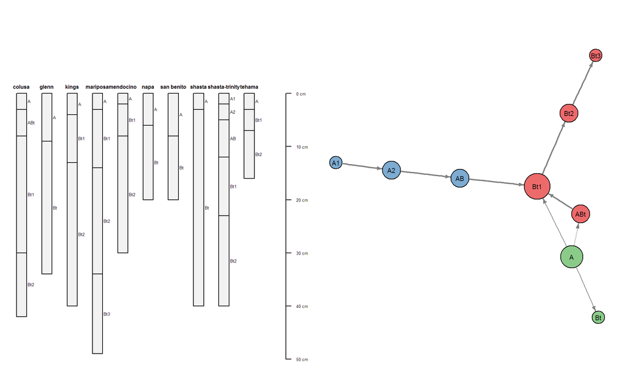

Graph constructed from transition probabilities. Thicker lines denote more likely transitions.

```r
# abuse sharpshootR code to display as graph
par(mar = c(0, 0, 0, 0), mfcol = c(1, 2))
plot(sp4)
plotSoilRelationGraph(tp, graph.mode = "directed", edge.arrow.size = 0.5, edge.scaling.factor = 2, vertex.label.cex = 0.75,
    vertex.label.family = "sans")
```

More examples.

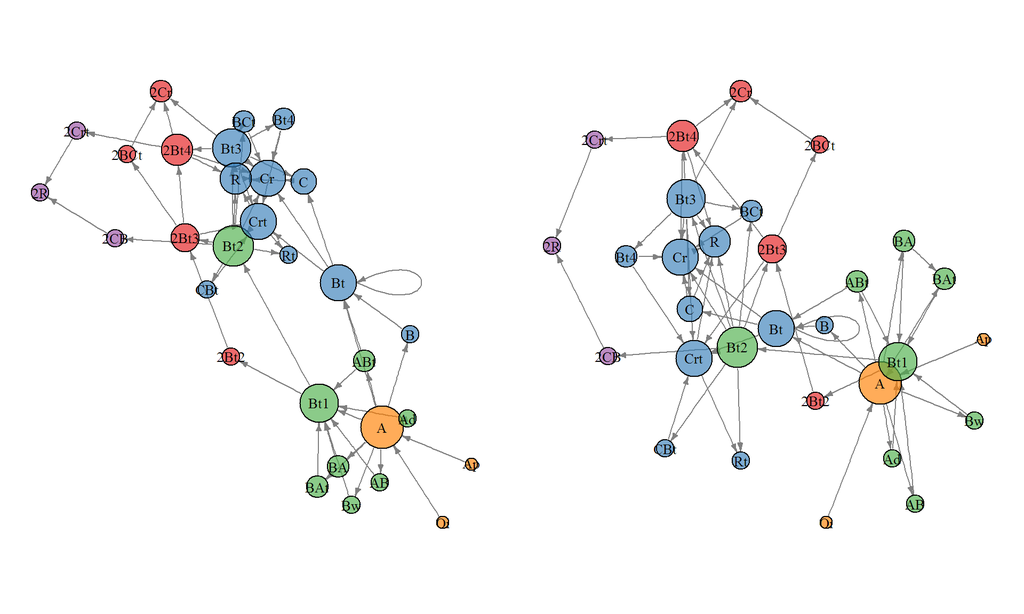

```r
# try some other examples, seems logical
tp <- hzTransitionProbabilities(pedons, "hzname")
# tp <- hzTransitionProbabilities(pedons, 'genhz')

# abuse sharpshootR code sometimes default layout doesn't look so good
par(mar = c(0, 0, 0, 0), mfcol = c(1, 2))
plotSoilRelationGraph(tp, graph.mode = "directed", edge.arrow.size = 0.5)
plotSoilRelationGraph(tp, graph.mode = "directed", edge.arrow.size = 0.5, g.layout = layout_with_lgl)
```

Convert contingency table of generalized horizon labels to an adjacency (similar to transition probability) matrix.

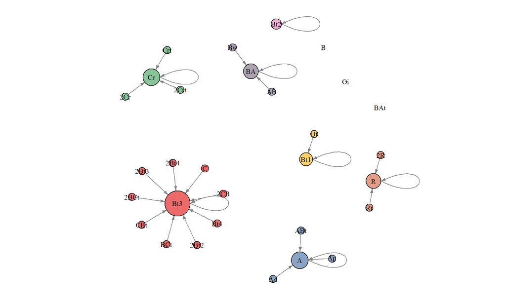

```r
tab <- table(pedons$hzname, pedons$genhz)
m <- genhzTableToAdjMat(tab)

par(mar = c(0, 0, 0, 0), mfcol = c(1, 1))
plotSoilRelationGraph(m, graph.mode = "directed", edge.arrow.size = 0.5)
```

Tinker with the [markovchain](https://cran.rstudio.com/web/packages/markovchain/index.html) package. Details [here](https://cran.rstudio.com/web/packages/markovchain/vignettes/an_introduction_to_markovchain_package.pdf).

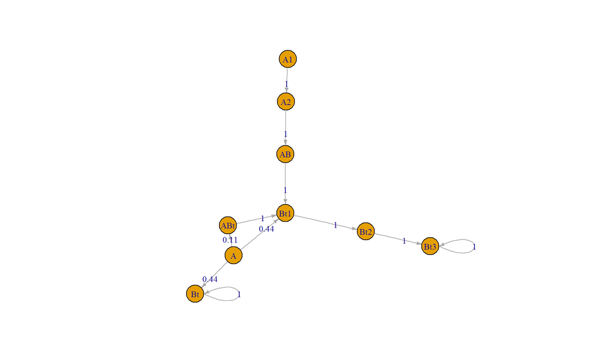

```r
## init a markovchain object from TP this trquires 'looping' terminal states e.g. an absorbing MC:
## https://en.wikipedia.org/wiki/Absorbing_Markov_chain
tp.loops <- hzTransitionProbabilities(sp4, "name", loopTerminalStates = TRUE)

mc <- new("markovchain", states = dimnames(tp.loops)[[1]], transitionMatrix = tp.loops)

# simple plot
plot(mc, edge.arrow.size = 0.5)
```

```r
# check absorbing states
absorbingStates(mc)
```

```
## [1] "Bt"  "Bt3"
```

```r
# steady-state:
steadyStates(mc)
```

| A | A1 | A2 | AB | ABt | Bt | Bt1 | Bt2 | Bt3 |
| --- | --- | --- | --- | --- | --- | --- | --- | --- |
| 0 | 0 | 0 | 0 | 0 | 1 | 0 | 0 | 0 |
| 0 | 0 | 0 | 0 | 0 | 0 | 0 | 0 | 1 |

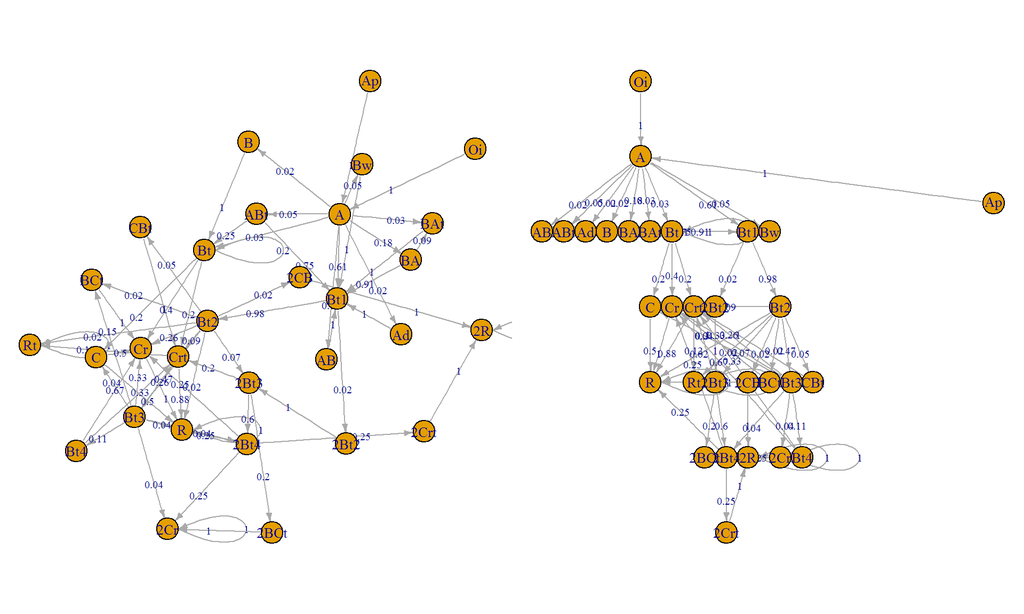

```r
# try some more complex TP matrices
tp <- hzTransitionProbabilities(pedons, "hzname", loopTerminalStates = TRUE)
mc <- new("markovchain", states = dimnames(tp)[[1]], transitionMatrix = tp)

# better plotting
par(mar = c(0, 0, 0, 0), mfcol = c(1, 2))
plot(mc, vertex.size = 10, edge.arrow.size = 0.5, edge.label.cex = 0.75, layout = layout_with_lgl)
plot(mc, vertex.size = 10, edge.arrow.size = 0.5, edge.label.cex = 0.75, layout = layout_as_tree)
```

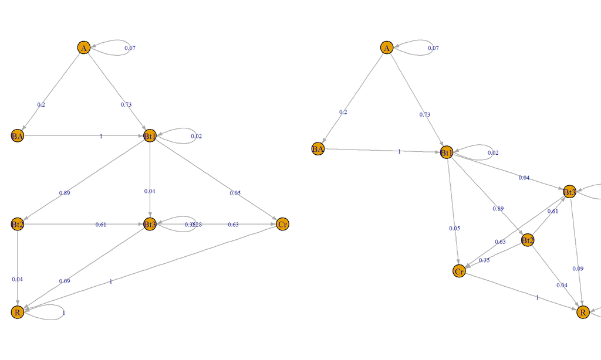

```r
# another
tp <- hzTransitionProbabilities(pedons, "genhz", loopTerminalStates = TRUE)
mc <- new("markovchain", states = dimnames(tp)[[1]], transitionMatrix = tp)

# better plotting
par(mar = c(0, 0, 0, 0), mfcol = c(1, 2))
plot(mc, vertex.size = 10, edge.arrow.size = 0.5, edge.label.cex = 0.75, layout = layout_as_tree)
plot(mc, vertex.size = 10, edge.arrow.size = 0.5, edge.label.cex = 0.75, layout = layout_with_lgl)
```

Simulation from a markovchain object.

```r
# simulate
rmarkovchain(10, mc, include.t0 = TRUE, t0 = "A")
```

```
##  [1] "A"   "Bt1" "Cr"  "R"   "R"   "R"   "R"   "R"   "R"   "R"   "R"
```

```r
# multiple simulations, as column vectors
replicate(10, rmarkovchain(10, mc, include.t0 = TRUE, t0 = "A"))
```

| A | A | A | A | A | A | A | A | A | A |
| --- | --- | --- | --- | --- | --- | --- | --- | --- | --- |
| Bt1 | Bt1 | Bt1 | Bt1 | Bt1 | Bt1 | BA | Bt1 | BA | A |
| Bt2 | Bt2 | Bt2 | Bt2 | Bt2 | Bt2 | Bt1 | Bt2 | Bt1 | Bt1 |
| Cr | Cr | Cr | Bt3 | Cr | Bt3 | Bt2 | Bt3 | Bt2 | Bt2 |
| R | R | R | R | R | Bt3 | Bt3 | Cr | Cr | Bt3 |
| R | R | R | R | R | Cr | Cr | R | R | Cr |
| R | R | R | R | R | R | R | R | R | R |
| R | R | R | R | R | R | R | R | R | R |
| R | R | R | R | R | R | R | R | R | R |
| R | R | R | R | R | R | R | R | R | R |
| R | R | R | R | R | R | R | R | R | R |

```r
# what comes after a state?
conditionalDistribution(mc, "A")
```

```
##          A         BA        Bt1        Bt2        Bt3         Cr          R
## 0.06666667 0.20000000 0.73333333 0.00000000 0.00000000 0.00000000 0.00000000
```

```r
# this is now in AQP, but requires markovchain package
mostLikelyHzSequence(mc, "A")
```

```
## [1] "A"   "Bt1" "Bt2" "Bt3" "Cr"  "R"
```

Try with some KSSL data.

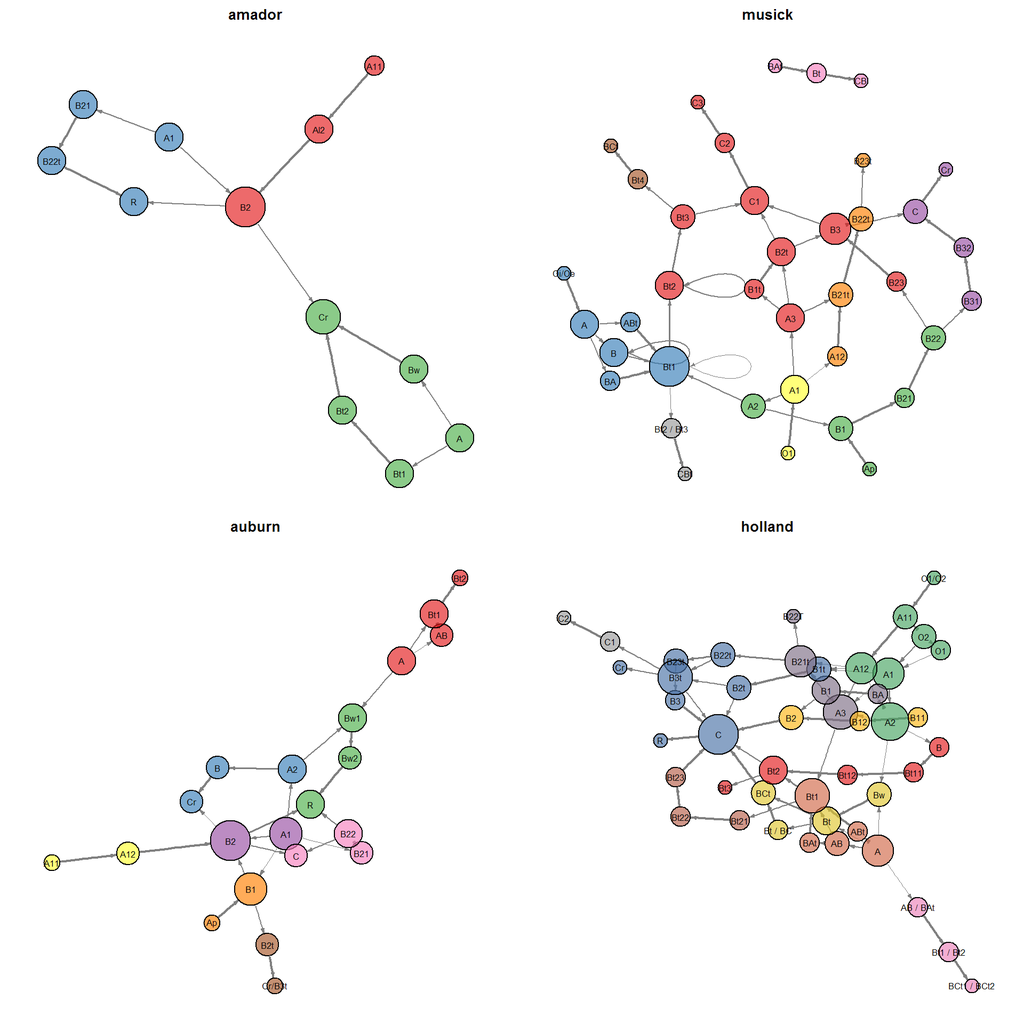

```r
# some series to query
s <- c("amador", "auburn", "musick", "holland")
s.data <- lapply(s, fetchKSSL)

par(mar = c(0, 0, 2, 0), mfcol = c(2, 2))
for (i in 1:length(s)) {
    tp <- hzTransitionProbabilities(s.data[[i]], "hzn_desgn")
    plotSoilRelationGraph(tp, graph.mode = "directed", edge.arrow.size = 0.3, edge.scaling.factor = 2,
        main = s[i], vertex.label.cex = 0.75, vertex.label.family = "sans")
}
```